# serp: An R package for smoothing in ordinal regression

# A minimal Example

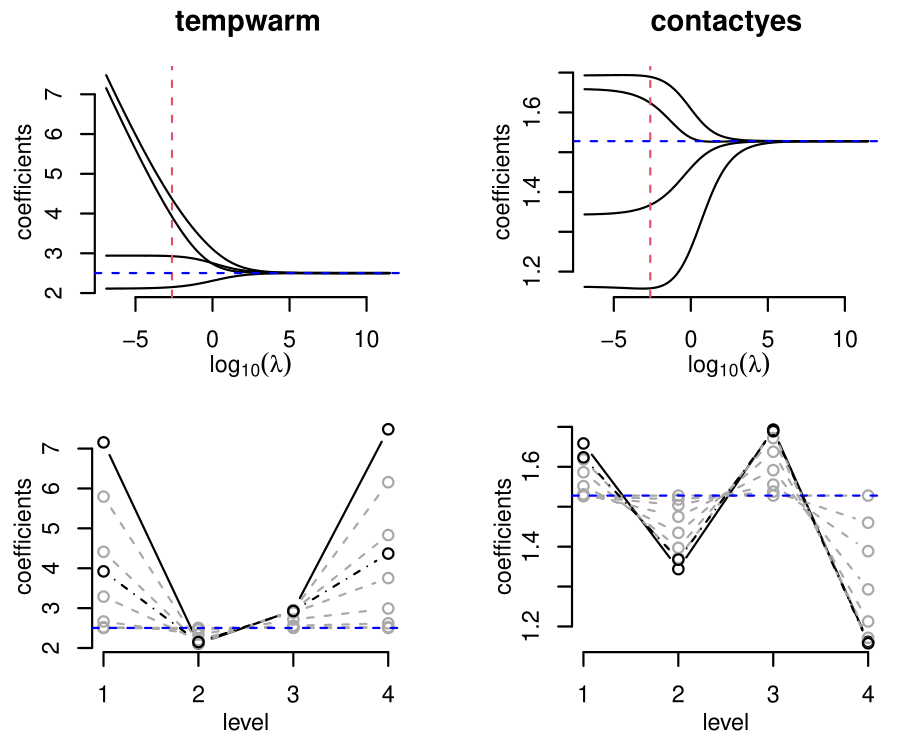

Estimates and standard errors (in parenthesis) of regression coefficients of the non-penalized (via vglm) and penalized (via serp) NPOM of the wine dataset, with Temperature:warm (TW) and Contact:yes (CY) as predictors.

| Coefficients | vglm | serp |
| --- | --- | --- |
| (Intercept):1 | 1.226 (0.557) | 1.255 (0.556) |
| (Intercept):2 | -1.033 (0.481) | -1.061 (0.480) |
| (Intercept):3 | -3.946 (0.902) | -3.926 (0.881) |
| (Intercept):4 | -19.184 (>$10^3$) | -6.497 (2.486) |
| TW:1 | 19.243 (>$10^3$) | 3.922 (2.333) |
| TW:2 | 2.111 (0.601) | 2.149 (0.600) |
| TW:3 | 2.940 (0.828) | 2.927 (0.810) |
| TW:4 | 17.064 (>$10^3$) | 4.368 (2.415) |
| CY:1 | 1.659 (1.179) | 1.624 (1.126) |
| CY:2 | 1.343 (0.583) | 1.367 (0.580) |
| CY:3 | 1.693 (0.660) | 1.689 (0.652) |
| CY:4 | 1.162 (0.905) | 1.158 (0.892) |

# Conclusion

Beyond the highlighted regularization functionality, provides a collection of tools that promote stress-free ordinal regression modeling in empirical research. Moreover, standard function names and arguments already known to users familiar with related libraries are also used in , reducing unnecessary ambiguity. Lastly, details about usage and more elaborate examples are hosted online through a pkgdown (Wickham and Hesselberth 2020) website on [Github Pages](https://ejikeugba.github.io/serp).

# Acknowledgements

A special thanks to Prof Dr. Jan Gertheiss for his invaluable suggestions and contributions towards the development of .

# References

Agresti, A. 2002. *Categorical Data Analysis*. 2nd ed. New York: John Wiley; Sons.

Archer, K J. 2014a. “Glmnetcr: Fit a Penalized Constrained Continuation Ratio Model for Predicting an Ordinal Response.” https://cran.r-project.org/package=glmnetcr.

———. 2014b. “Glmpathcr: Fit a Penalized Continuation Ratio Model for Predicting an Ordinal Response.” https://cran.r-project.org/package=glmpathcr.

Archer, K J, J Hou, Q Zhou, K Ferber, J G Layne, and A E Gentry. 2014. “Ordinalgmifs: An R Package for Ordinal Regression in Highdimensional Data Settings.” *Cancer Informatics* 13: 187–95.

Buhmann, P, and S Van de Geer. 2011. *Statistics for High-Dimensional Data: Methods, Theory and Applications*. Berlin/Heidelberg: Springer.

Fisher, F. 1966. *The Identification Problem in Econometrics*. McGraw-Hill.

Greenberg, Edward, and Charles E. Jr. Webster. 1983. *Advanced Econometrics: A Bridge to the Literature*. New York: John Wiley.

Harrell, F. 2015. *Regression Modeling Strategies: With Applications to Linear Models, Logistic and Ordinal Regression, and Survival Analysis*. Springer.

Hoerl, A, and R Kennard. 1970. “Ridge Regression: Biased Estimation for Nonorthogonal Problems.” *Technometrics* 12: 55–67.

McCullagh, P. 1980. “Regression Models for Ordinal Data.” *Journal of the Royal Statistical Society. Series B (Methodological)* 42: 109–42.

Randall, J. 1989. “The Analysis of Sensory Data by Generalised Linear Model.” *Biometrics* 7: 781–93.

R Core Team. 2021. *R: A Language and Environment for Statistical Computing*. Vienna, Austria: R Foundation for Statistical Computing. https://www.R-project.org/.

SAS Institute Inc. 2021. *SAS/Stat User’s Guide Procedures*. Cary, NC: SAS Institute Inc. http://support.sas.com/documentation/onlinedoc/stat/indexproc.html.

Tibshirani, R. 1996. “Regression Shrinkage and Selection via the Lasso.” *Journal of the Royal Statistical Society. Series B (Methodological)* 58: 267–88.

Tutz, G, and J Gertheiss. 2016. “Regularized Regression for Categorical Data (with Discussion and Rejoinder).” *Statistical Modelling* 16: 161–260.

Ugba, E R. 2021. “Serp: Smooth Effects on Response Penalty for Clm.” https://CRAN.R-project.org/package=serp.

Ugba, E R, D Mörlein, and J Gertheiss. 2021. “Smoothing in Ordinal Regression: An Application to Sensory Data.” *Stats* 4: 616–33. https://doi.org/10.3390/stats4030037.

Wickham, H, and J Hesselberth. 2020. “Pkgdown: Make Static Html Documentation for a Package.” https://CRAN.R-project.org/package=pkgdown.

Wood, S N, N Pya, and B Saefken. 2016. “Smoothing Parameter and Model Selection for General Smooth Models.” *Journal of the American Statistical Association* 111: 1548–75. https://doi.org/10.1080/01621459.2016.1180986.

Wurm, M J, P J Rathouz, and B M Hanlon. 2017. “Regularized Ordinal Regression and the ordinalNet R Package.” *ArXiv Preprint, arXiv:1706.05003*.

Yee, T W. 2010. “The Vgam Package for Categorical Data Analysis.” *J. Statist. Soft.* 32: 1–34.

Yee, T W, and C J Wild. 1996. “Vector Generalized Additive Models.” *Journal of the Royal Statistical Society. Series B: Statistical Methodology* 58: 481–93.

Zou, H, and T Hastie. 2005. “Regularization and Variable Selection via the Elastic Net.” *Journal of the Royal Statistical Society. Series B (Methodological)* 67: 301–20.